# Regresión Lineal Múltiple I

Juan Barriola y Sofía Perini

3 de Octubre de 2020

## Planteo del problema

Nuestro objetivo es crear un modelo lineal múltiple para explicar el sueldo neto de Data Analysts, Data Scientists y Data Engineers en Argentina.

Nuestra idea subyacente de cómo se puede explicar el salario neto es:

$salarioNeto = \beta_0 +\beta_1X_1+\beta_2X_2+...+\epsilon$

```r
library(tidyverse)
library(tidymodels)
```

## Levantamos Dataset

Vamos a trabajar con el subconjunto de datos que surgió del trabajo de limpieza que se hizo en la clase de regresión lineal simple, correspondiente al grupo de salarios de los data scientists/analyst, de la encuesta de sueldos en el sector de tecnología en Argenina realizada por SysArmy. El informe, realizado por OpenQube lo pueden ver [acá](https://sueldos.openqube.io/encuesta-sueldos-2020.01/).

```r
encuesta <- read_csv("../Fuentes/encuesta_RLM_limpia.csv")
getwd()
```

```
[1] "/home/ktavo/Disks/SSD/Git Projects/UBA_2020/EEA-2021/clase 5"
```

La limpieza consistió en: eliminar los outliers de acuerdo a los criterios de la clase 3, descartar los sueldos dolarizados, eliminar los registros inconsistentes con la edad laboral, aquellas inconsistencias en las variables sueldo bruto y neto, como también aquellos errores de carga en los años de experiencia y las inconsistencias en relación con los años en la empresa actual, quedando como resultado un dataset de 159 observaciones, con el que trabajaremos a continuación (98 DA y 61 DS).

### Seleccionamos variables de interés

```r
df <- encuesta %>%
  select(me_identifico, edad, donde_estas_trabajando, anos_de_experiencia, anos_en_la_empresa_actual, anos_en_el_puesto_actual, gente_a_cargo, trabajo_de, nivel_de_estudios_alcanzado, estado, salario_bruto, salario_neto) %>%
  # creamos la variable perfil
  mutate(perfil = factor(case_when(trabajo_de == "BI Analyst / Data Analyst" ~ "DA", trabajo_de == "Data Scientist / Data Engineer" ~ "DS")))
df %>%
  head()
```

| me_identifico | edad | donde_estas_trabajando | anos_de_experiencia | anos_en_la_empresa_actual | anos_en_el_puesto_actual | gente_a_cargo | trabajo_de | nivel_de_estudios_alcanzado | estado | salario_bruto | salario_neto | perfil |
| --- | --- | --- | --- | --- | --- | --- | --- | --- | --- | --- | --- | --- |
| Hombre | 34 | Formosa | 9 | 5 | 5 | 0 | BI Analyst / Data Analyst | Universitario | Completado | 140000 | 80000 | DA |
| Hombre | 28 | Santa Fe | 3 | 1 | 3 | 0 | BI Analyst / Data Analyst | Universitario | Incompleto | 54000 | 45000 | DA |
| Hombre | 31 | C\xf3rdoba | 12 | 0 | 0 | 0 | BI Analyst / Data Analyst | Terciario | Completado | 55000 | 40000 | DA |
| Mujer | 28 | Santa Fe | 2 | 1 | 1 | 0 | BI Analyst / Data Analyst | Universitario | Completado | 41700 | 34600 | DA |
| Mujer | 29 | Santa Fe | 3 | 2 | 3 | 1 | BI Analyst / Data Analyst | Universitario | Completado | 50000 | 42000 | DA |
| Hombre | 28 | Ciudad Aut\xf3noma de Buenos Aires | 5 | 0 | 0 | 0 | Data Scientist / Data Engineer | Universitario | Completado | 220000 | 120000 | DS |

Recordemos cómo era la correlación entre las variables numéricas seleccionadas.

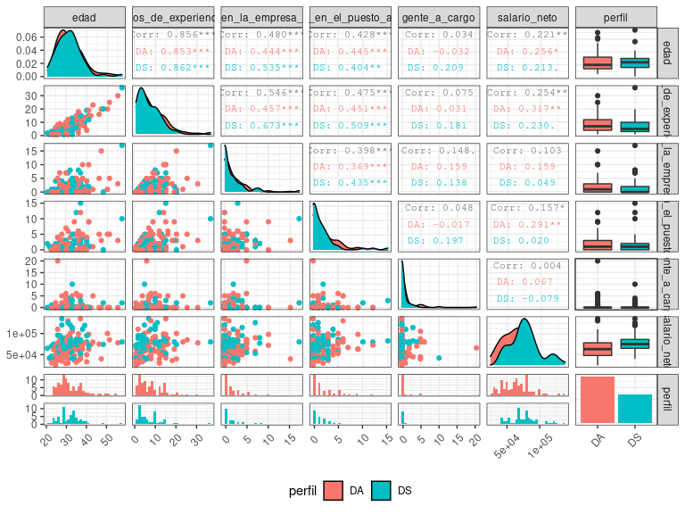

```r
library(GGally)
df %>%
  select(edad, anos_de_experiencia, anos_en_la_empresa_actual, anos_en_el_puesto_actual, gente_a_cargo, salario_neto, perfil) %>%
  ggpairs(., aes(color = perfil),
          upper = list(continuous = wrap("cor", size = 3, hjust=0.5)), legend = 25) +
  theme_bw() +
  theme(axis.text.x = element_text(angle=45, vjust=0.5), legend.position = "bottom")
```

## Modelo Múltiple

El modelo de **regresión lineal múltiple** es un modelo para la variable aleatoria Y cuando se conocen las variables regresoras. Es múltiple ya que vincula una serie de variables predictoras con Y.

El modelo en términos de las variables:

$$Y_i = β_0 + β_1X_{i1} + β_2X_{i2} + · · · + β_{p-1}X_{ip-1} + ε_i$$
donde $β_0$, $β_1$,.., $β_{p−1}$ son parámetros desconocidos, $X_{i1}$, $X_{i2}$, …, $X_{ip-1}$ son los valores de las variables predictoras medidas en el i-ésimo individuo, $Y_i$ es la variable respuesta medida en el i-ésimo individuo (observado) y $ε_i$ es el error para el individuo i-ésimo (no observable).

**Supuestos del modelo lineal**

Se pueden resumir como $ϵ_i$ ~ $N(0,σ^2)$ para todo $1<i<n$, independientes entre sí.

El modelo en términos de la esperanza condicional de Y dadas $X_1$, $X_2$,…, $X_{p-1}$:

$$E(Y|X_1,X_2,...X_{p-1}) = β_0 + β_1X_{i1} + β_2X_{i2} + · · · + β_{p-1}X_{ip-1}$$

El modelo se denomina *lineal* puesto que la esperanza de Y condicional a las X’s depende linealmente de las covariables $X_1$, $X_2$,…, $X_{p-1}$.

### Estimación de los Parámetros (ajuste del modelo)

Se quiere ajustar un modelo para el salario neto en función de 2 variables:

$salarioNeto = \beta_0 + \beta_1x_{i1} + \beta_2x_{i2} + \epsilon_i$

Veamos cómo se interpretan los ajustes para los distintos tipos de predictores.

### *1) Predictores numéricos*

Armemos un modelo para predecir el salario_neto en función de los años de experiencia y la gente_a_cargo. Veamos los resultados del modelo empleando la función tidy().

```r
# ajustamos modelo lineal multiple
modelo_exp_gc <- lm(salario_neto ~ anos_de_experiencia + gente_a_cargo, data = df)
# Resumen del modelo
tidy_meg <- tidy(modelo_exp_gc, conf.int = TRUE)
tidy_meg
```

| term | estimate | std.error | statistic | p.value | conf.low | conf.high |
| --- | --- | --- | --- | --- | --- | --- |
| (Intercept) | 61303.0503 | 2885.4658 | 21.2454604 | 6.646280e-48 | 55603.4257 | 67002.675 |
| anos_de_experiencia | 967.2370 | 294.6401 | 3.2827744 | 1.268699e-03 | 385.2381 | 1549.236 |
| gente_a_cargo | -158.3054 | 811.5898 | -0.1950559 | 8.456030e-01 | -1761.4286 | 1444.818 |

#### Significado de los coeficientes estimados

- El valor de la ordenada al origen (61.303) es el valor de salario neto **esperado** para alguien sin experiencia laboral (0 años de experiencia) y sin gente a cargo, es decir, para alguien que recién comienza.
- El coeficiente estimado de años de experiencia es 967,23. Si mantenemos el número de gente a cargo constante, cada incremento de un año en los años de experiencia corresponde a un aumento de 967 pesos, **en promedio** en el sueldo neto. O lo que es igual, dadas dos personas con la misma cantidad de gente a cargo pero teniendo uno un año más de experiencia que el otro, el sueldo neto **esperado** para el de mayor experiencia será 967 pesos más alto que el de menor experiencia.

¿Cómo se interpretaría el coeficiente estimado de gente a cargo?